# Multi-Level Linguistic Alignment in a Dynamic CPS Tasks: Step 3 Model 1: Lexical

Nick Duran

01/15/22

> Notebook contains code for replicating section in manuscript: Analysis 1: Alignment over time

### Step 1: Import main data file and run script to prep variables for analysis

```r
library(tidyverse)
library(pander)

rm(list=ls())
```

```r
main.data = read.csv("../Data/Step1_PrepareFeatures.csv")

source("../R_Helper/Step3_helper.R")
main.data.20 = variable_prep(main.data)

pander(names(main.data.20))
```

*Team*, *School*, *Block*, *Concept*, *Goal*, *Level*, *trophy*, *level_duration*, *relative_start_time*, *revisited*, *speaker_target*, *aligner_score*, *aligner_role*, *utterlen_target*, *utterlen_aligner*, *semantic*, *lexical*, *syn2nd*, *syn3nd*, *syntax*, *ordering_prop*, *level_durationZ*, *utterlen_targetZ*, *utterlen_alignerZ*, *relative_start_timeZ*, *Block.l*, *subject_id* and *team_id*

```r
# head(main.data.20)
```

- Relies heavily on “Step3_helper.R.” This code does the following:
  - remove levels that are fewer than 20 turns
  - Convert # of turns to a running proportion score
  - Get z-scores for relevant variables
  - create ordered factor for block (interested in linear trend)
  - create random factor for within subject variance (making sure each unique subject is signified given their school and team)

### Step 2: Check the distributions of the main outcome linguistic variables

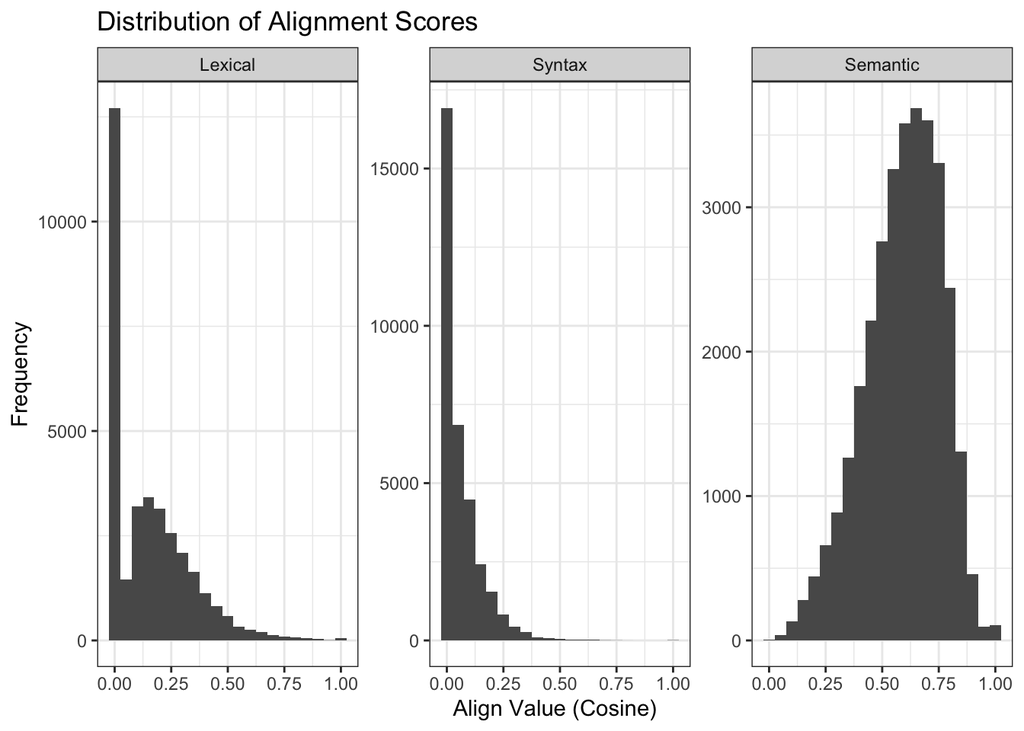

```r
g1 = main.data.20 %>% select(lexical, syntax, semantic)
head(g1)
```

```
## # A tibble: 6 × 3
##   lexical syntax semantic
##     <dbl>  <dbl>    <dbl>
## 1  0      0         0.417
## 2  0      0         0.413
## 3  0.2    0         0.653
## 4  0.0845 0.0256    0.823
## 5  0.126  0         0.772
## 6  0.0527 0.0114    0.722
```

### Step 3: Build and test models: Lexical

```r
# library(glmmTMB) ## no longer using
library(lme4) ## for glmer
library(strengejacke) ## for tab_model and plot_model
library(parameters)
library(lmtest) ## for lrtest
library(bbmle) ## for AICtab
```

Setup for separating prevalence from magnitude

```r
GHM.data.20 = main.data.20 %>% mutate(non_zero_lex = ifelse(lexical > 0, 1, 0))
```

#### Binomial logistic model

##### Model selection tests: interceptVSslope

To start, lets examine the binomial logistic model by first comparing two plausible random effect structures (while avoiding convergence issues).

Run the models:

```r
z1.glmer1 <- glmer(non_zero_lex ~ ordering_prop + Block.l + aligner_role + relative_start_timeZ + level_durationZ + utterlen_alignerZ + Concept + (1|subject_id), binomial(link = "logit"), data = GHM.data.20)
```

```r
z1.glmer2 <- glmer(non_zero_lex ~ ordering_prop + Block.l + aligner_role + relative_start_timeZ + level_durationZ + utterlen_alignerZ + Concept + (aligner_role|subject_id), binomial(link = "logit"), data = GHM.data.20)
```

Compare the two models based on comparing log-likelihood/AIC with various tests.

```r
# AICtab
AICtab(z1.glmer1,z1.glmer2,logLik=TRUE)
```

```
##           dLogLik dAIC df
## z1.glmer2  3.3     0.0 12
## z1.glmer1  0.0     2.6 10
```

```r
# lrtest
lrtest(z1.glmer1,z1.glmer2)
```

```
## Likelihood ratio test
##
## Model 1: non_zero_lex ~ ordering_prop + Block.l + aligner_role + relative_start_timeZ +
##     level_durationZ + utterlen_alignerZ + Concept + (1 | subject_id)
## Model 2: non_zero_lex ~ ordering_prop + Block.l + aligner_role + relative_start_timeZ +
##     level_durationZ + utterlen_alignerZ + Concept + (aligner_role |
##     subject_id)
##   #Df LogLik Df  Chisq Pr(>Chisq)
## 1  10 -20935
## 2  12 -20932  2 6.6016    0.03685 *
## ---
## Signif. codes:  0 '***' 0.001 '**' 0.01 '*' 0.05 '.' 0.1 ' ' 1
```

##### Model selection tests: randomVSnone

Lets examine the summary structure of the preferred model, now focusing on the appropriateness of the random effects of the model. It does seem that the role|subject variance is very small. Is this variance relevant? Next step is to compare this effect with a model where we pool/ignore the role|subject effect.

```r
summary(z1.glmer2)
```

```
## Generalized linear mixed model fit by maximum likelihood (Laplace
##   Approximation) [glmerMod]
##  Family: binomial  ( logit )
## Formula:
## non_zero_lex ~ ordering_prop + Block.l + aligner_role + relative_start_timeZ +
##     level_durationZ + utterlen_alignerZ + Concept + (aligner_role |
##     subject_id)
##    Data: GHM.data.20
##
##      AIC      BIC   logLik deviance df.resid
##  41887.1  41988.3 -20931.5  41863.1    34000
##
## Scaled residuals:
##      Min       1Q   Median       3Q      Max
## -13.7244  -1.0171   0.5162   0.8303   1.2912
##
## Random effects:
##  Groups     Name                   Variance Std.Dev. Corr
##  subject_id (Intercept)            0.03504  0.1872
##             aligner_rolecontroller 0.01236  0.1112   -0.95
## Number of obs: 34012, groups:  subject_id, 280
##
## Fixed effects:
##                         Estimate Std. Error z value Pr(>|z|)
## (Intercept)             0.614294   0.029729  20.663  < 2e-16 ***
## ordering_prop          -0.027374   0.039677  -0.690 0.490251
## Block.l.L              -0.067955   0.022431  -3.029 0.002450 **
## Block.l.Q               0.029730   0.021225   1.401 0.161285
## aligner_rolecontroller  0.093583   0.025557   3.662 0.000251 ***
## relative_start_timeZ    0.026101   0.013577   1.922 0.054549 .
## level_durationZ         0.052184   0.014871   3.509 0.000450 ***
## utterlen_alignerZ       0.826116   0.018171  45.464  < 2e-16 ***
## ConceptPoT              0.002293   0.027754   0.083 0.934168
## ---
## Signif. codes:  0 '***' 0.001 '**' 0.01 '*' 0.05 '.' 0.1 ' ' 1
##
## Correlation of Fixed Effects:
##             (Intr) ordrn_ Blc..L Blc..Q algnr_ rlt__Z lvl_dZ uttr_Z
## orderng_prp -0.668
## Block.l.L    0.097 -0.001
## Block.l.Q   -0.062  0.001 -0.085
## algnr_rlcnt -0.409  0.003 -0.005 -0.015
## rltv_strt_Z  0.026  0.000  0.035 -0.039  0.006
## level_drtnZ -0.058  0.001  0.095  0.060 -0.009  0.442
## uttrln_lgnZ  0.115  0.009  0.002 -0.003  0.094 -0.003 -0.022
## ConceptPoT  -0.337  0.000 -0.314  0.226  0.001 -0.076  0.174  0.002
```

```r
z1.glm2 <- glm(non_zero_lex ~ ordering_prop + Block.l + aligner_role + relative_start_timeZ + level_durationZ + utterlen_alignerZ + Concept, binomial(link = "logit"), data = GHM.data.20)
```

```r
# AICtab
AICtab(z1.glm2,z1.glmer2,logLik=TRUE)
```

```
##           dLogLik dAIC df
## z1.glmer2 18.6     0.0 12
## z1.glm2    0.0    31.1 9
```

```r
#Method 2: lrtest : CANNOT RUN THIS TEST BECAUSE TWO DIFFERENT MODEL CLASSES!
```

##### Model selection tests: fullVsnull

Next, after making some observations about the random effects structure, lets see of the full model is better than the null model. Here we might be on more solid footing in using the LR-test.

```r
z1.glmer2.null <- glmer(non_zero_lex ~ 1 + (aligner_role|subject_id), binomial(link = "logit"), data = GHM.data.20)
```

```r
# AICtab
AICtab(z1.glmer2.null,z1.glmer2,logLik=TRUE)
```

```
##                dLogLik dAIC   df
## z1.glmer2      1498.1     0.0 12
## z1.glmer2.null    0.0  2980.2 4
```

```r
# lrtest
lrtest(z1.glmer2.null,z1.glmer2)
```

```
## Likelihood ratio test
##
## Model 1: non_zero_lex ~ 1 + (aligner_role | subject_id)
## Model 2: non_zero_lex ~ ordering_prop + Block.l + aligner_role + relative_start_timeZ +
##     level_durationZ + utterlen_alignerZ + Concept + (aligner_role |
##     subject_id)
##   #Df LogLik Df  Chisq Pr(>Chisq)
## 1   4 -22430
## 2  12 -20932  8 2996.2  < 2.2e-16 ***
## ---
## Signif. codes:  0 '***' 0.001 '**' 0.01 '*' 0.05 '.' 0.1 ' ' 1
```

##### Interpreting

Let’s get to interpreting the effects. These results can be reported as “log effect estimates” and exponentiated for “odds ratios.”

```r
# model_parameters(z1.glmer2, exponentiate = T, digits=3)
```

```r
model_parameters(z1.glmer2, exponentiate = F, digits=3)
```

```
## # Fixed Effects
##
## Parameter                 | Log-Odds |    SE |         95% CI |      z |      p
## -------------------------------------------------------------------------------
## (Intercept)               |    0.614 | 0.030 | [ 0.56,  0.67] | 20.663 | < .001
## ordering prop             |   -0.027 | 0.040 | [-0.11,  0.05] | -0.690 | 0.490
## Block l [linear]          |   -0.068 | 0.022 | [-0.11, -0.02] | -3.029 | 0.002
## Block l [quadratic]       |    0.030 | 0.021 | [-0.01,  0.07] |  1.401 | 0.161
## aligner role [controller] |    0.094 | 0.026 | [ 0.04,  0.14] |  3.662 | < .001
## relative start timeZ      |    0.026 | 0.014 | [ 0.00,  0.05] |  1.922 | 0.055
## level durationZ           |    0.052 | 0.015 | [ 0.02,  0.08] |  3.509 | < .001
## utterlen alignerZ         |    0.826 | 0.018 | [ 0.79,  0.86] | 45.464 | < .001
## Concept [PoT]             |    0.002 | 0.028 | [-0.05,  0.06] |  0.083 | 0.934
##
## # Random Effects
##
## Parameter                                          | Coefficient
## ----------------------------------------------------------------
## SD (Intercept: subject_id)                         |       0.187
## SD (aligner_rolecontroller: subject_id)            |       0.111
## Cor (Intercept~aligner_rolecontroller: subject_id) |      -0.952
## SD (Residual)                                      |       1.000
```

```r
# Now generating the % change from the non-exponentiated coefficients to facilitate reporting
(1-(exp(-0.068))) * 100
```

```
## [1] 6.573953
```

#### Gamma models

##### Model selection tests: interceptVSslope

```r
g1.glmer1 <- glmer(lexical ~ ordering_prop + Block.l + aligner_role + relative_start_timeZ + level_durationZ + utterlen_alignerZ + Concept + (1|subject_id), family = Gamma(link = log), data = subset(GHM.data.20, non_zero_lex == 1), control=glmerControl(optimizer="bobyqa"))
```

```r
g1.glmer2 <- glmer(lexical ~ ordering_prop + Block.l + aligner_role + relative_start_timeZ + level_durationZ + utterlen_alignerZ + Concept + (aligner_role|subject_id), family = Gamma(link = log), data = subset(GHM.data.20, non_zero_lex == 1), control=glmerControl(optimizer="bobyqa"))
```

Compare the two models based on comparing log-likelihood/AIC with various tests.

```r
# AICtab
AICtab(g1.glmer1,g1.glmer2,logLik=TRUE)
```

```
##           dLogLik dAIC df
## g1.glmer2 23.5     0.0 13
## g1.glmer1  0.0    43.0 11
```

```r
# lrtest
lrtest(g1.glmer1,g1.glmer2)
```

```
## Likelihood ratio test
##
## Model 1: lexical ~ ordering_prop + Block.l + aligner_role + relative_start_timeZ +
##     level_durationZ + utterlen_alignerZ + Concept + (1 | subject_id)
## Model 2: lexical ~ ordering_prop + Block.l + aligner_role + relative_start_timeZ +
##     level_durationZ + utterlen_alignerZ + Concept + (aligner_role |
##     subject_id)
##   #Df LogLik Df  Chisq Pr(>Chisq)
## 1  11  13086
## 2  13  13110  2 46.995  6.241e-11 ***
## ---
## Signif. codes:  0 '***' 0.001 '**' 0.01 '*' 0.05 '.' 0.1 ' ' 1
```

##### Model selection tests: randomVSnone

Lets examine the summary structure of the preferred model, now focusing on the appropriateness of the random effects of the model. Again, role|subject variance is very small. Is this variance relevant? Next step is to compare this effect with a model where we pool/ignore the role|subject effect.

```r
summary(g1.glmer2)
```

```
## Generalized linear mixed model fit by maximum likelihood (Laplace
##   Approximation) [glmerMod]
##  Family: Gamma  ( log )
## Formula:
## lexical ~ ordering_prop + Block.l + aligner_role + relative_start_timeZ +
##     level_durationZ + utterlen_alignerZ + Concept + (aligner_role |
##     subject_id)
##    Data: subset(GHM.data.20, non_zero_lex == 1)
## Control: glmerControl(optimizer = "bobyqa")
##
##      AIC      BIC   logLik deviance df.resid
## -26193.9 -26090.3  13109.9 -26219.9    21314
##
## Scaled residuals:
##     Min      1Q  Median      3Q     Max
## -1.5249 -0.7443 -0.2074  0.5212  5.2751
##
## Random effects:
##  Groups     Name                   Variance Std.Dev. Corr
##  subject_id (Intercept)            0.005607 0.07488
##             aligner_rolecontroller 0.009861 0.09930  -0.46
##  Residual                          0.377266 0.61422
## Number of obs: 21327, groups:  subject_id, 280
##
## Fixed effects:
##                         Estimate Std. Error  t value Pr(>|z|)
## (Intercept)            -1.353406   0.011585 -116.822  < 2e-16 ***
## ordering_prop          -0.035047   0.014011   -2.501 0.012371 *
## Block.l.L              -0.002319   0.009031   -0.257 0.797346
## Block.l.Q              -0.005514   0.008514   -0.648 0.517243
## aligner_rolecontroller -0.046546   0.012052   -3.862 0.000112 ***
## relative_start_timeZ    0.010673   0.004814    2.217 0.026615 *
## level_durationZ        -0.001131   0.005848   -0.193 0.846653
## utterlen_alignerZ      -0.053562   0.003722  -14.390  < 2e-16 ***
## ConceptPoT             -0.008645   0.011111   -0.778 0.436516
## ---
## Signif. codes:  0 '***' 0.001 '**' 0.01 '*' 0.05 '.' 0.1 ' ' 1
##
## Correlation of Fixed Effects:
##             (Intr) ordrn_ Blc..L Blc..Q algnr_ rlt__Z lvl_dZ uttr_Z
## orderng_prp -0.603
## Block.l.L    0.114  0.000
## Block.l.Q   -0.064  0.008 -0.066
## algnr_rlcnt -0.380  0.001 -0.007 -0.010
## rltv_strt_Z  0.028 -0.004  0.023 -0.037  0.001
## level_drtnZ -0.068 -0.003  0.087  0.054  0.000  0.405
## uttrln_lgnZ -0.105  0.026  0.010 -0.009  0.076 -0.017 -0.057
## ConceptPoT  -0.348 -0.001 -0.317  0.205  0.001 -0.081  0.158 -0.008
```

```r
g1.glm2 <- glm(lexical ~ ordering_prop + Block.l + aligner_role + relative_start_timeZ + level_durationZ + utterlen_alignerZ + Concept, family = Gamma(link = log), data = subset(GHM.data.20, non_zero_lex == 1))
```

```r
# AICtab
AICtab(g1.glm2,g1.glmer2,logLik=TRUE)
```

```
##           dLogLik dAIC  df
## g1.glmer2  95.4     0.0 13
## g1.glm2     0.0   184.7 10
```

##### Model selection tests: fullVsnull

Next, after making some observations about the random effects structure, lets see of the full model is better than the null model. Here we might be on more solid footing in using the LR-test.

```r
g1.glmer2.null <- glmer(lexical ~ 1 + (aligner_role|subject_id), family = Gamma(link = log), data = subset(GHM.data.20, non_zero_lex == 1), control=glmerControl(optimizer="bobyqa"))
```

```r
# AICtab
AICtab(g1.glmer2.null,g1.glmer2,logLik=TRUE)
```

```
##                dLogLik dAIC  df
## g1.glmer2      110.1     0.0 13
## g1.glmer2.null   0.0   204.2 5
```

```r
# lrtest
lrtest(g1.glmer2.null,g1.glmer2)
```

```
## Likelihood ratio test
##
## Model 1: lexical ~ 1 + (aligner_role | subject_id)
## Model 2: lexical ~ ordering_prop + Block.l + aligner_role + relative_start_timeZ +
##     level_durationZ + utterlen_alignerZ + Concept + (aligner_role |
##     subject_id)
##   #Df LogLik Df  Chisq Pr(>Chisq)
## 1   5  13000
## 2  13  13110  8 220.16  < 2.2e-16 ***
## ---
## Signif. codes:  0 '***' 0.001 '**' 0.01 '*' 0.05 '.' 0.1 ' ' 1
```

##### Interpreting

Let’s get to interpreting the effects. These results can be reported as “log effect estimates” and exponentiated for “odds ratios.”

```r
# model_parameters(g1.glmer2, exponentiate = T, digits=3)
```

```r
model_parameters(g1.glmer2, exponentiate = F, digits=3)
```

```
## # Fixed Effects
##
## Parameter                 | Coefficient |    SE |         95% CI | t(21314) |      p
## ------------------------------------------------------------------------------------
## (Intercept)               |      -1.353 | 0.012 | [-1.38, -1.33] | -116.822 | < .001
## ordering prop             |      -0.035 | 0.014 | [-0.06, -0.01] |   -2.501 | 0.012
## Block l [linear]          |      -0.002 | 0.009 | [-0.02,  0.02] |   -0.257 | 0.797
## Block l [quadratic]       |      -0.006 | 0.009 | [-0.02,  0.01] |   -0.648 | 0.517
## aligner role [controller] |      -0.047 | 0.012 | [-0.07, -0.02] |   -3.862 | < .001
## relative start timeZ      |       0.011 | 0.005 | [ 0.00,  0.02] |    2.217 | 0.027
## level durationZ           |      -0.001 | 0.006 | [-0.01,  0.01] |   -0.193 | 0.847
## utterlen alignerZ         |      -0.054 | 0.004 | [-0.06, -0.05] |  -14.390 | < .001
## Concept [PoT]             |      -0.009 | 0.011 | [-0.03,  0.01] |   -0.778 | 0.437
##
## # Random Effects
##
## Parameter                                          | Coefficient
## ----------------------------------------------------------------
## SD (Intercept: subject_id)                         |       0.075
## SD (aligner_rolecontroller: subject_id)            |       0.099
## Cor (Intercept~aligner_rolecontroller: subject_id) |      -0.456
## SD (Residual)                                      |       0.614
```

```r
(1-(exp(-0.035))) * 100
```

```
## [1] 3.439458
```

### Step 4: Create visuals

Let’s start with rate incidence/odds ratio as a forest plot using “plot_model” with modifications

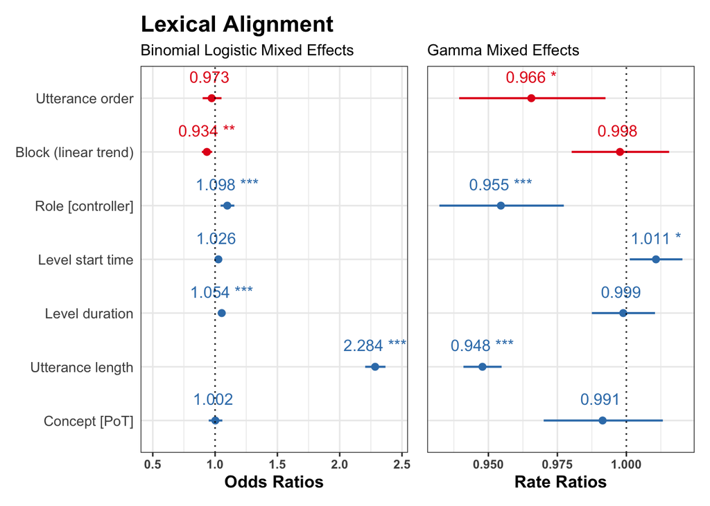

```r
library(patchwork)
alignPlotLex = pz.l + pg.l
alignPlotLex
```

```r
# alignPlotLex + plot_annotation(tag_levels = 'A')
```

```r
ggsave(filename = "Figs/lexical_forest.png",width = 8, height = 4.5, dpi = 300, units = "in", device='png')
```

```r
save.image(file = "lexical.RData")
```